# Valuation & Benefit-Cost Analysis

Lecture

James Doss-Gollin

Monday, February 9, 2026

# A Decision Problem

Today

1. A Decision Problem
2. Utility Theory
3. Dealing with Time
4. Handling Uncertainty
5. Worked Example: House Elevation
6. Critiques & Defense
7. Wrap-Up

## How Much Would You Pay?

Imagine you own a home in Houston’s Meyerland neighborhood.

- Your house flooded in 2015, 2016, *and* 2017
- A contractor offers to elevate your house by 5 feet for **$80,000**
- Should you do it?

## What Do We Need to Know?

- What does elevation cost? (up-front + disruption)
- What are the benefits? (avoided flood damage, insurance savings, peace of mind)
- How likely is future flooding?
- How long do we plan to live there?
- How do we compare costs *now* vs. benefits *later*?

# Utility Theory

Today

1. A Decision Problem
2. Utility Theory
3. Dealing with Time
4. Handling Uncertainty
5. Worked Example: House Elevation
6. Critiques & Defense
7. Wrap-Up

## Utility Functions

We need a way to score how “good” a decision is. Define a **utility function**:

$$u(a, \mathbf{s}): \mathcal{A} \times \mathcal{S} \to \mathbb{R}$$

- $a \in \mathcal{A}$: a decision (or **a**ction)
- $\mathbf{s} \in \mathcal{S}$: the **s**tate of the world (everything uncertain)
- $u$: maps (decision, state) to a real number

## Choosing Your Metric

You are **free** to define “goodness” however you want.

- Monetary cost
- Lives saved
- Acres of wetland preserved
- Some weighted combination

This is a feature, not a bug — but it means every BCA embeds **value judgments**.

## Money as a Common Unit

Utility is often measured in **dollars**.

Not because money is all that matters, but because it provides a common unit for comparing different things.

**Tip**

For house elevation, monetary costs and benefits include:

- Up-front construction cost
- Change in flood insurance premiums
- Change in property value
- Expected future flood damages avoided

## Opportunity Costs

How do we put a dollar value on something that isn’t traded in a market?

**Opportunity cost**: the value of the next best alternative.

- If we can protect one square mile of pristine wetland for $1 million, that’s the cost of *not* protecting a comparable square mile elsewhere
- If a household spends 10 hours per flood event cleaning up, the value of their time is an opportunity cost
- But: are these really substitutes?

## Decreasing Marginal Utility

A key insight from economics: the **more** you have of something, the **less** each additional unit is worth.

[output not shown]

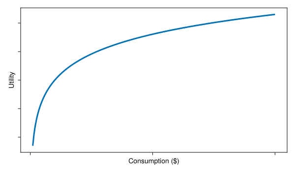

Each additional dollar of consumption provides less additional utility.

```julia
using CairoMakie

let
    fig = Figure(; size=(600, 350))
    ax = Axis(
        fig[1, 1];
        xlabel="Consumption (\$)",
        ylabel="Utility",
        xticklabelsvisible=false,
        yticklabelsvisible=false,
        xgridvisible=false,
        ygridvisible=false,
    )
    x = range(0.1, 10; length=200)
    lines!(ax, x, log.(x); linewidth=3)
    fig
end
```

## Implication: Distribution and Social Welfare

If marginal utility decreases with wealth:

- A dollar of damage hurts a low-income household **more** than a wealthy one
- Standard BCA treats a dollar the same regardless of who receives it
- And there is **no single “right” way** to aggregate individual welfare into social welfare

We will revisit equity and values later in the semester.

# Dealing with Time

Today

1. A Decision Problem
2. Utility Theory
3. Dealing with Time
4. Handling Uncertainty
5. Worked Example: House Elevation
6. Critiques & Defense
7. Wrap-Up

## Costs Now, Benefits Later

Climate adaptation costs and benefits are spread over **decades**.

How should we weigh a dollar of benefit 30 years from now against a dollar of cost today?

## Net Present Value

**Discount** future values to the present using discount rate $r$:

$$NPV(a, \mathbf{s}) = \sum_{t=0}^{T} \frac{B_t(a, \mathbf{s}) - C_t(a, \mathbf{s})}{(1 + r)^t}$$

- $B_t - C_t$: net benefits (benefits minus costs) in year $t$
- $r$: discount rate (e.g., 2% per year)
- $\frac{1}{(1+r)^t}$: how much we value a dollar $t$ years from now
- $T$: time horizon

## Alternative Notation

You will also see NPV written as:

$$NPV(a, \mathbf{s}) = \sum_{t=0}^{T} (1 - \gamma)^t \left[ B_t(a, \mathbf{s}) - C_t(a, \mathbf{s}) \right]$$

- These are **mathematically equivalent** — just different parameterizations
- Our formula: discount rate $r$, discount factor $\frac{1}{(1+r)^t}$
- Alternative: discount rate $\gamma$, discount factor $(1-\gamma)^t$
- Relationship: $(1 - \gamma) = \frac{1}{1+r}$, so $\gamma = \frac{r}{1+r}$

**Important**

Always check which convention a paper or report uses — a “2% discount rate” gives different numbers depending on the formula!

## Worked Example

At $r = 2\%$, what is **$1** in 10 years worth today?

$$\frac{1}{(1.02)^{10}} \approx \$0.82$$

What about **$1** in 50 years?

$$\frac{1}{(1.02)^{50}} \approx \$0.37$$

At $r = 7\%$: $1 in 50 years $= \frac{1}{(1.07)^{50}} \approx \$0.03$

# Handling Uncertainty

Today

1. A Decision Problem
2. Utility Theory
3. Dealing with Time
4. Handling Uncertainty
5. Worked Example: House Elevation
6. Critiques & Defense
7. Wrap-Up

## How BCA Is Commonly Practiced

Most real-world analyses pick a **single “best guess”** scenario.

- A Houston water utility picks **one assumption** for each uncertain input (population, climate, regulations, costs)
- Calculate NPV under this single scenario
- If NPV > 0, the project “passes”

## Why Single-Scenario BCA Is Fragile

Decisions that look great under one scenario can fail badly under another.

- Build a reservoir for future demand → but what if future is **drier** than expected? (Reservoir doesn’t fill)
- Build a reservoir for future demand → but what if future is **wetter** than expected? (Reservoir was unnecessary — funds should have gone to flood protection)
- The “best guess” is almost certainly wrong in some dimension

## Expected Utility

A better approach: pick the decision with the best **expected** NPV:

$$a^* = \arg \max_a \; \mathbb{E}_{\mathbf{s}} \left[ NPV(a, \mathbf{s}) \right]$$

Recall:

$$\mathbb{E}_{\mathbf{s}} \left[ NPV(a, \mathbf{s}) \right] = \int p(\mathbf{s}) \, NPV(a, \mathbf{s}) \, d\mathbf{s}$$

This requires a **probability distribution** over states of the world.

## Connecting to Monte Carlo

You already know how to do this!

1. Sample many states of the world $\mathbf{s}_1, \mathbf{s}_2, \ldots, \mathbf{s}_N$ from $p(\mathbf{s})$
2. Compute $NPV(a, \mathbf{s}_i)$ for each sample
3. Average: $\hat{\mathbb{E}}[NPV(a,\mathbf{s})] \approx \frac{1}{N}\sum_{i=1}^N NPV(a, \mathbf{s}_i)$
4. Compare across actions $a \in \mathcal{A}$

## The Standard BCA Recipe

1. Define the set of actions $\mathcal{A}$ (e.g., elevate by 0, 3, 5, or 8 feet)
2. Define costs and benefits $B_t(a, \mathbf{s})$, $C_t(a, \mathbf{s})$
3. Choose a discount rate $r$
4. Estimate $p(\mathbf{s})$ — probability distribution over states of the world
5. Pick $a^* = \arg \max_a \; \mathbb{E}[NPV(a, \mathbf{s})]$

# Worked Example: House Elevation

Today

1. A Decision Problem
2. Utility Theory
3. Dealing with Time
4. Handling Uncertainty
5. Worked Example: House Elevation
6. Critiques & Defense
7. Wrap-Up

## Setting Up the Problem

Return to our Meyerland homeowner. Two actions: **do nothing** ($a_0$) or **elevate 5 ft** ($a_1$).

|  | Do Nothing ($a_0$) | Elevate 5 ft ($a_1$) |
| --- | --- | --- |
| Up-front cost | $0 | $80,000 |
| Annual flood probability | 5% | 0.5% |
| Expected damage per flood | $50,000 | $5,000 |
| **Expected annual damage** | **$2,500** | **$25** |

## Computing NPV

Annual benefit of elevation: $\$2{,}500 - \$25 = \$2{,}475$ per year in avoided damages.

Over $T = 30$ years at discount rate $r$:

$$NPV = -\$80{,}000 + \sum_{t=1}^{30} \frac{\$2{,}475}{(1+r)^t}$$

| Discount rate $r$ | PV of benefits | NPV | Pass? |
| --- | --- | --- | --- |
| 2% | $55,500 | **-$24,500** | No |
| 5% | $38,000 | **-$42,000** | No |
| 7% | $30,700 | **-$49,300** | No |

At these numbers, elevation doesn’t pass BCA at *any* discount rate. What would need to change?

## Sensitivity: What If Flood Risk Is Higher?

Suppose climate change increases annual flood probability to **10%** (EAD: $5,000/yr, benefit: $4,975/yr):

| Discount rate $r$ | PV of benefits | NPV | Pass? |
| --- | --- | --- | --- |
| 2% | $111,500 | **+$31,500** | Yes |
| 5% | $76,500 | **-$3,500** | Barely no |
| 7% | $61,700 | **-$18,300** | No |

The **same project** passes or fails depending on two assumptions: flood probability and discount rate.

# Critiques & Defense

Today

1. A Decision Problem
2. Utility Theory
3. Dealing with Time
4. Handling Uncertainty
5. Worked Example: House Elevation
6. Critiques & Defense
7. Wrap-Up

## White House Circular A-94

The 2023 revision of federal BCA guidance (U.S. Office of Management and Budget, 2023):

- Intended to govern how federal agencies conduct BCA
- Lowered the default discount rate from 7% to ~2%
- Expanded guidance on equity and distributional effects
- Its current status is uncertain under the new administration

## The Discount Rate Problem

Two rationales for discounting (Arrow et al., 2013):

1. **Consumption-based** (~3%): Future generations will be richer, so an extra dollar matters less to them
2. **Investment-based** (~7%): A dollar invested today yields more than a dollar in the future

Both assume future generations are better off — what if climate change makes them *worse* off?

## High Discount Rates Favor Inaction

At $r = 7\%$, damages 50 years out are worth **$0.03** today.

- Infrastructure with 50-100 year lifetimes
- Sea-level rise over centuries
- Species extinction is permanent

The discount rate can determine whether a project “passes” BCA — more than any other single parameter.

## Decision-Support, Not Decision-Making

**Important**

BCA is a tool for **informing** decisions, not **making** them.

- It forces us to be explicit about our assumptions
- Applied well, it’s iterative refinement of understanding; applied poorly, it’s a black box that justifies a decision already made
- The number matters less than what you learn by computing it

# Wrap-Up

Today

1. A Decision Problem
2. Utility Theory
3. Dealing with Time
4. Handling Uncertainty
5. Worked Example: House Elevation
6. Critiques & Defense
7. Wrap-Up

## Key Takeaways

1. BCA provides a systematic framework for comparing decisions — but every analysis embeds value judgments
2. Utility theory gives us the math; opportunity costs, discounting, and expected value give us the tools
3. The discount rate is a choice, not a fact — and it can flip a project from “fails” to “passes”
4. BCA is decision-*support*: the assumptions matter more than the final number

## Wednesday Preview

**Paper Discussion:** Discounting & BCA

- Read Arrow et al. (2013)
- Optional: skim U.S. Office of Management and Budget (2023)
- Before class: look up how **one federal agency** (USACE, EPA, FEMA, or TWDB) conducts BCA — what discount rate do they use? What counts as a benefit?
- Come ready to discuss: which rationale for discounting do you find most convincing?

## References

Arrow, K., Cropper, M., Gollier, C., Groom, B., Heal, G., Newell, R., et al. (2013). Determining benefits and costs for future generations. *Science*, *341*(6144), 349–350. https://doi.org/10.1126/science.1235665

U.S. Office of Management and Budget. (2023). *Circular No. A-94: Guidelines and Discount Rates for Benefit-Cost Analysis of Federal Programs* (Circular). Executive Office of the President. Retrieved from https://www.whitehouse.gov/wp-content/uploads/2023/11/CircularA-94.pdf